# Exam 6

Alice, Kseniia, ShanShan

02 06 2026

# 1 Environment setting

```r
#plotting for all task
if (!require("ggplot2")) { install.packages("ggplot2"); library("ggplot2") }
#imputation data for task5
if (!require("mice")) { install.packages("mice"); library("mice") }
#different logistic models comparison for task5
if (!require("sjPlot")) { install.packages("sjPlot"); library("sjPlot") }
#Variance Inflation Factor (VIF) diagnostics for task5
if (!require("car")) { install.packages("car"); library("car") }
#regression summaries for task5
if (!require("gtsummary")) { install.packages("gtsummary"); library("gtsummary") }
#ROC and AUC analysis for task5
if (!require("pROC")) { install.packages("pROC"); library("pROC") }
#machine learning for task5
if (!require("randomForest")) { install.packages("randomForest"); library("randomForest") }
```

# 2 Task 1

1. Load and clean the data sets. Give an overview over the different variables analyze them descriptively.
2. Analyze the differences between the genders descriptively.

```r
# 1.1 load and clean the datasets
dat1 <- read.csv("Exam_6_1.csv")
summary(dat1)
```

```
##        X             Name                Age           Gender
##  Min.   :    1   Length:55500       Min.   :13.00   Length:55500
##  1st Qu.:13876   Class :character   1st Qu.:35.00   Class :character
##  Median :27750   Mode  :character   Median :52.00   Mode  :character
##  Mean   :27750                      Mean   :51.54
##  3rd Qu.:41625                      3rd Qu.:68.00
##  Max.   :55500                      Max.   :89.00
##   Blood.Type        Medical.Condition  Date.of.Admission     Doctor
##  Length:55500       Length:55500       Length:55500       Length:55500
##  Class :character   Class :character   Class :character   Class :character
##  Mode  :character   Mode  :character   Mode  :character   Mode  :character
##
##
##
##    Hospital         Insurance.Provider Billing.Amount      Room.Number
##  Length:55500       Length:55500       Length:55500       Min.   :101.0
##  Class :character   Class :character   Class :character   1st Qu.:202.0
##  Mode  :character   Mode  :character   Mode  :character   Median :302.0
##                                                           Mean   :301.1
##                                                           3rd Qu.:401.0
##                                                           Max.   :500.0
##  Admission.Type     Discharge.Date      Medication        Test.Results
##  Length:55500       Length:55500       Length:55500       Length:55500
##  Class :character   Class :character   Class :character   Class :character
##  Mode  :character   Mode  :character   Mode  :character   Mode  :character
##
##
##
```

```r
# uppercase all names
dat1$Name <- toupper(dat1$Name)
# fix the comma instead of dot issue
dat1$Billing.Amount <- gsub(",", ".", dat1$Billing.Amount)
# set negative values of billing amount as NA
dat1$Billing.Amount[dat1$Billing.Amount < 0] = NA

# omit first column
dat1 <- dat1[, -1]

# find and remove duplicates
sum(duplicated(dat1))
```

```
## [1] 527
```

```r
dat1 <- dat1[!duplicated(dat1), ]

# fix variable type
dat1$Date.of.Admission <- as.Date(dat1$Date.of.Admission, "%Y-%m-%d")
dat1$Discharge.Date <- as.Date(dat1$Discharge.Date, "%Y-%m-%d")
dat1$Admission.Type <- as.factor(dat1$Admission.Type)
dat1$Blood.Type <- as.factor(dat1$Blood.Type)
dat1$Gender <- as.factor(dat1$Gender)
dat1$Doctor <- as.factor(dat1$Doctor)
dat1$Name <- as.factor(dat1$Name)
dat1$Insurance.Provider <- as.factor(dat1$Insurance.Provider)
dat1$Medical.Condition <- as.factor(dat1$Medical.Condition)
dat1$Test.Results <- as.factor(dat1$Test.Results)
dat1$Room.Number <- as.factor(dat1$Room.Number)
dat1$Billing.Amount <- as.numeric(dat1$Billing.Amount)
dat1$Medication <- as.factor(dat1$Medication)

# calculate duration of hospitalization
dat1$Duration.of.Hospitalization <- as.numeric(dat1$Discharge.Date - dat1$Date.of.Admission)

# remove all missing values
clean_dat1 <- na.omit(dat1)
summary(clean_dat1)
```

```
##                Name            Age           Gender        Blood.Type
##  MICHAEL SMITH   :   23   Min.   :13.00   Female:27248   A+     : 6839
##  MICHAEL WILLIAMS:   23   1st Qu.:35.00   Male  :27288   A-     : 6838
##  ROBERT SMITH    :   21   Median :52.00                  B+     : 6836
##  JAMES BROWN     :   18   Mean   :51.53                  AB+    : 6833
##  JAMES SMITH     :   18   3rd Qu.:68.00                  B-     : 6822
##  JAMES GARCIA    :   16   Max.   :89.00                  AB-    : 6809
##  (Other)         :54417                                  (Other):13559
##     Medical.Condition Date.of.Admission                Doctor
##  Arthritis   :9163    Min.   :2019-05-08   Michael Smith  :   27
##  Asthma      :9022    1st Qu.:2020-07-28   John Smith     :   22
##  Cancer      :9073    Median :2021-11-02   Robert Smith   :   21
##  Diabetes    :9137    Mean   :2021-11-01   Michael Johnson:   20
##  Hypertension:9072    3rd Qu.:2023-02-04   David Smith    :   19
##  Obesity     :9069    Max.   :2024-05-07   James Smith    :   19
##                                            (Other)        :54408
##    Hospital                Insurance.Provider Billing.Amount
##  Length:54536       Aetna           :10733    Min.   :    9.239
##  Class :character   Blue Cross      :10880    1st Qu.:13300.097
##  Mode  :character   Cigna           :11050    Median :25589.922
##                     Medicare        :10944    Mean   :25592.069
##                     UnitedHealthcare:10929    3rd Qu.:37832.980
##                                               Max.   :52764.277
##
##   Room.Number      Admission.Type  Discharge.Date             Medication
##  393    :  175   Elective :18331   Min.   :2019-05-09   Aspirin    :10893
##  420    :  174   Emergency:17965   1st Qu.:2020-08-12   Ibuprofen  :10931
##  104    :  173   Urgent   :18240   Median :2021-11-18   Lipitor    :10954
##  209    :  170                     Mean   :2021-11-17   Paracetamol:10887
##  491    :  170                     3rd Qu.:2023-02-19   Penicillin :10871
##  392    :  169                     Max.   :2024-06-06
##  (Other):53505
##        Test.Results   Duration.of.Hospitalization
##  Abnormal    :18285   Min.   : 1.0
##  Inconclusive:18075   1st Qu.: 8.0
##  Normal      :18176   Median :15.0
##                       Mean   :15.5
##                       3rd Qu.:23.0
##                       Max.   :30.0
##
```

```r
# load and clean data2
dat2 <- read.csv("Exam_6_2.csv")
summary(dat2)
```

```
##    patient_id         age           gender               bmi
##  Min.   :10000   Min.   :40.00   Length:3000        Min.   : 8.80
##  1st Qu.:10750   1st Qu.:52.00   Class :character   1st Qu.:24.80
##  Median :11500   Median :65.00   Mode  :character   Median :28.10
##  Mean   :11500   Mean   :65.25                      Mean   :28.11
##  3rd Qu.:12249   3rd Qu.:78.00                      3rd Qu.:31.50
##  Max.   :12999   Max.   :90.00                      Max.   :44.90
##                                                     NA's   :90
##       bnp             sodium        creatinine      systolic_bp
##  Min.   :  50.0   Min.   :124.7   Min.   :-0.590   Min.   : 61.0
##  1st Qu.: 225.0   1st Qu.:135.3   1st Qu.: 0.870   1st Qu.:116.0
##  Median : 392.0   Median :138.1   Median : 1.200   Median :130.0
##  Mean   : 406.3   Mean   :138.1   Mean   : 1.195   Mean   :129.6
##  3rd Qu.: 569.0   3rd Qu.:140.8   3rd Qu.: 1.520   3rd Qu.:143.0
##  Max.   :1381.0   Max.   :151.6   Max.   : 2.940   Max.   :196.0
##                   NA's   :90      NA's   :90
##    heart_rate     ace_inhibitor     beta_blocker       diuretic
##  Min.   : 19.00   Min.   :0.0000   Min.   :0.0000   Min.   :0.000
##  1st Qu.: 69.00   1st Qu.:0.0000   1st Qu.:0.0000   1st Qu.:0.000
##  Median : 79.00   Median :1.0000   Median :1.0000   Median :0.000
##  Mean   : 79.36   Mean   :0.5217   Mean   :0.5033   Mean   :0.489
##  3rd Qu.: 90.00   3rd Qu.:1.0000   3rd Qu.:1.0000   3rd Qu.:1.000
##  Max.   :147.00   Max.   :1.0000   Max.   :1.0000   Max.   :1.000
##
##  adherence_score  income_level       distance_to_hospital_km readmitted_30d
##  Min.   :0.4000   Length:3000        Min.   : 1.00           Min.   :0.0000
##  1st Qu.:0.5500   Class :character   1st Qu.:12.80           1st Qu.:0.0000
##  Median :0.7000   Mode  :character   Median :25.45           Median :0.0000
##  Mean   :0.6994                      Mean   :25.40           Mean   :0.4113
##  3rd Qu.:0.8500                      3rd Qu.:37.52           3rd Qu.:1.0000
##  Max.   :1.0000                      Max.   :50.00           Max.   :1.0000
##
```

```r
# fix variable types
dat2$patient_id <- as.factor(dat2$patient_id)
dat2$gender <- as.factor(dat2$gender)
dat2$ace_inhibitor <- as.factor(dat2$ace_inhibitor)
dat2$beta_blocker <- as.factor(dat2$beta_blocker)
dat2$diuretic <- as.factor(dat2$diuretic)
dat2$income_level <- as.factor(dat2$income_level)
dat2$readmitted_30d <- as.factor(dat2$readmitted_30d)

# remove values that make no physiological sense
dat2$creatinine[dat2$creatinine < 0] = NA
dat2$bmi[dat2$bmi < 12] = NA

# find and remove duplicates
sum(duplicated(dat2))
```

```
## [1] 0
```

```r
dat2 <- dat2[!duplicated(dat2), ]

# we decided to delete missing data
clean_dat2 <- na.omit(dat2)
summary(clean_dat2)
```

```
##    patient_id        age           gender          bmi             bnp
##  10000  :   1   Min.   :40.00   Female:1366   Min.   :12.50   Min.   :  50.0
##  10001  :   1   1st Qu.:52.00   Male  :1354   1st Qu.:24.90   1st Qu.: 224.0
##  10002  :   1   Median :66.00                 Median :28.10   Median : 391.0
##  10003  :   1   Mean   :65.38                 Mean   :28.15   Mean   : 406.3
##  10004  :   1   3rd Qu.:78.00                 3rd Qu.:31.50   3rd Qu.: 569.0
##  10005  :   1   Max.   :90.00                 Max.   :44.90   Max.   :1381.0
##  (Other):2714
##      sodium        creatinine     systolic_bp      heart_rate     ace_inhibitor
##  Min.   :124.7   Min.   :0.000   Min.   : 62.0   Min.   : 19.00   0:1306
##  1st Qu.:135.3   1st Qu.:0.880   1st Qu.:116.0   1st Qu.: 69.00   1:1414
##  Median :138.1   Median :1.200   Median :130.0   Median : 79.00
##  Mean   :138.1   Mean   :1.204   Mean   :129.7   Mean   : 79.53
##  3rd Qu.:140.8   3rd Qu.:1.520   3rd Qu.:143.0   3rd Qu.: 90.00
##  Max.   :151.6   Max.   :2.890   Max.   :196.0   Max.   :147.00
##
##  beta_blocker diuretic adherence_score  income_level distance_to_hospital_km
##  0:1336       0:1381   Min.   :0.4000   High  :880   Min.   : 1.00
##  1:1384       1:1339   1st Qu.:0.5500   Low   :929   1st Qu.:12.68
##                        Median :0.7000   Medium:911   Median :25.55
##                        Mean   :0.6986                Mean   :25.39
##                        3rd Qu.:0.8500                3rd Qu.:37.60
##                        Max.   :1.0000                Max.   :50.00
##
##  readmitted_30d
##  0:1587
##  1:1133
##
##
##
##
##
```

```r
# 1.2 Analyze differences between the genders descriptively
by(clean_dat1, clean_dat1$Gender, summary)
```

```
## clean_dat1$Gender: Female
##                Name            Age           Gender        Blood.Type
##  MICHAEL SMITH   :   14   Min.   :13.00   Female:27248   A+     :3506
##  ROBERT SMITH    :   13   1st Qu.:35.00   Male  :    0   O-     :3448
##  KIMBERLY SMITH  :   12   Median :52.00                  O+     :3411
##  MICHAEL WILLIAMS:   12   Mean   :51.58                  B-     :3398
##  JAMES GARCIA    :   10   3rd Qu.:69.00                  AB-    :3396
##  MATTHEW SMITH   :   10   Max.   :89.00                  A-     :3382
##  (Other)         :27177                                  (Other):6707
##     Medical.Condition Date.of.Admission                 Doctor
##  Arthritis   :4611    Min.   :2019-05-08   Michael Smith   :   15
##  Asthma      :4476    1st Qu.:2020-07-28   James Smith     :   12
##  Cancer      :4531    Median :2021-10-30   Jessica Johnson :   11
##  Diabetes    :4570    Mean   :2021-10-31   Michael Williams:   11
##  Hypertension:4529    3rd Qu.:2023-02-01   William Johnson :   11
##  Obesity     :4531    Max.   :2024-05-07   David Smith     :   10
##                                            (Other)         :27178
##    Hospital                Insurance.Provider Billing.Amount
##  Length:27248       Aetna           :5281     Min.   :   23.73
##  Class :character   Blue Cross      :5481     1st Qu.:13238.98
##  Mode  :character   Cigna           :5545     Median :25499.52
##                     Medicare        :5479     Mean   :25531.97
##                     UnitedHealthcare:5462     3rd Qu.:37749.96
##                                               Max.   :52764.28
##
##   Room.Number      Admission.Type Discharge.Date             Medication
##  209    :   99   Elective :9212   Min.   :2019-05-11   Aspirin    :5521
##  198    :   92   Emergency:9092   1st Qu.:2020-08-12   Ibuprofen  :5493
##  393    :   92   Urgent   :8944   Median :2021-11-15   Lipitor    :5463
##  112    :   91                    Mean   :2021-11-16   Paracetamol:5349
##  389    :   90                    3rd Qu.:2023-02-17   Penicillin :5422
##  431    :   89                    Max.   :2024-06-06
##  (Other):26695
##        Test.Results  Duration.of.Hospitalization
##  Abnormal    :9166   Min.   : 1.00
##  Inconclusive:9080   1st Qu.: 8.00
##  Normal      :9002   Median :15.00
##                      Mean   :15.47
##                      3rd Qu.:23.00
##                      Max.   :30.00
```

[output cut: 28 more lines]

```
##  104    :   99   Elective :9119   Min.   :2019-05-09   Aspirin    :5372
##  214    :   95   Emergency:8873   1st Qu.:2020-08-13   Ibuprofen  :5438
##  478    :   94   Urgent   :9296   Median :2021-11-20   Lipitor    :5491
##  258    :   93                    Mean   :2021-11-18   Paracetamol:5538
##  144    :   89                    3rd Qu.:2023-02-21   Penicillin :5449
##  158    :   88                    Max.   :2024-06-03
##  (Other):26730
##        Test.Results  Duration.of.Hospitalization
##  Abnormal    :9119   Min.   : 1.00
##  Inconclusive:8995   1st Qu.: 8.00
##  Normal      :9174   Median :15.00
##                      Mean   :15.54
##                      3rd Qu.:23.00
##                      Max.   :30.00
##
```

```r
by(clean_dat2, clean_dat2$gender, summary)
```

```
## clean_dat2$gender: Female
##    patient_id        age           gender          bmi             bnp
##  10003  :   1   Min.   :40.00   Female:1366   Min.   :12.90   Min.   :  50.0
##  10005  :   1   1st Qu.:52.00   Male  :   0   1st Qu.:24.70   1st Qu.: 233.0
##  10006  :   1   Median :65.00                 Median :28.00   Median : 402.0
##  10007  :   1   Mean   :65.34                 Mean   :28.07   Mean   : 410.3
##  10012  :   1   3rd Qu.:79.00                 3rd Qu.:31.50   3rd Qu.: 563.8
##  10013  :   1   Max.   :90.00                 Max.   :44.90   Max.   :1381.0
##  (Other):1360
##      sodium        creatinine     systolic_bp      heart_rate     ace_inhibitor
##  Min.   :125.5   Min.   :0.030   Min.   : 67.0   Min.   : 19.00   0:652
##  1st Qu.:135.2   1st Qu.:0.890   1st Qu.:117.0   1st Qu.: 69.00   1:714
##  Median :138.0   Median :1.220   Median :131.0   Median : 80.00
##  Mean   :138.0   Mean   :1.215   Mean   :130.2   Mean   : 79.68
##  3rd Qu.:140.6   3rd Qu.:1.520   3rd Qu.:144.0   3rd Qu.: 90.00
##  Max.   :151.6   Max.   :2.890   Max.   :184.0   Max.   :147.00
##
##  beta_blocker diuretic adherence_score  income_level distance_to_hospital_km
##  0:683        0:690    Min.   :0.4000   High  :455   Min.   : 1.00
##  1:683        1:676    1st Qu.:0.5400   Low   :470   1st Qu.:12.43
##                        Median :0.6900   Medium:441   Median :25.40
##                        Mean   :0.6972                Mean   :25.06
##                        3rd Qu.:0.8500                3rd Qu.:37.20
##                        Max.   :1.0000                Max.   :49.90
##
##  readmitted_30d
##  0:800
##  1:566
##
##
##
##
##
## ------------------------------------------------------------
## clean_dat2$gender: Male
##    patient_id        age           gender          bmi             bnp
##  10000  :   1   Min.   :40.00   Female:   0   Min.   :12.50   Min.   :  50.0
##  10001  :   1   1st Qu.:53.00   Male  :1354   1st Qu.:24.93   1st Qu.: 215.5
##  10002  :   1   Median :66.00                 Median :28.30   Median : 378.5
##  10004  :   1   Mean   :65.41                 Mean   :28.22   Mean   : 402.3
```

[output cut: 12 more lines]

```
##  0:654         0:653        0:691    Min.   :0.40    High  :425
##  1:700         1:701        1:663    1st Qu.:0.55    Low   :459
##                                      Median :0.70    Medium:470
##                                      Mean   :0.70
##                                      3rd Qu.:0.85
##                                      Max.   :1.00
##
##  distance_to_hospital_km readmitted_30d
##  Min.   : 1.00           0:787
##  1st Qu.:13.03           1:567
##  Median :25.70
##  Mean   :25.72
##  3rd Qu.:37.80
##  Max.   :50.00
##
```

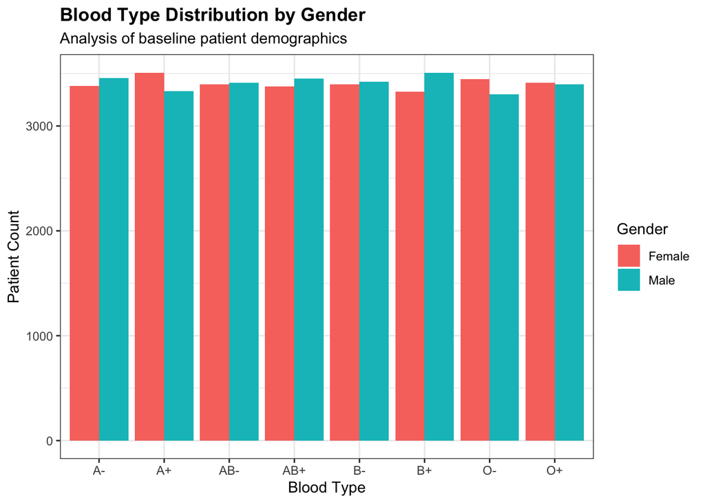

```r
# make the plots for gender differences
# gender differences in blood type

ggplot(clean_dat1, aes(x = Blood.Type, fill = Gender)) +
  geom_bar(position = "dodge") +
  theme_bw() +
  labs(title = "Blood Type Distribution by Gender",
       subtitle = "Analysis of baseline patient demographics",
       x = "Blood Type", y = "Patient Count") +
  theme(plot.title = element_text(face = "bold"))
```

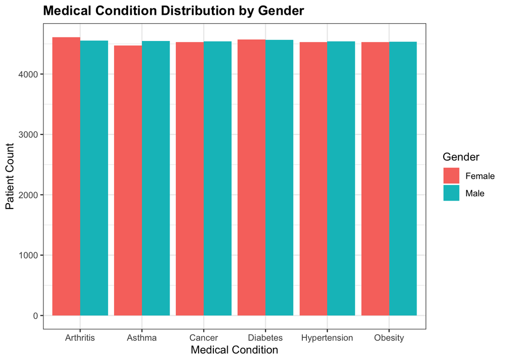

```r
# gender differences in medical condition
ggplot(clean_dat1, aes(x = Medical.Condition, fill = Gender)) +
  geom_bar(position = "dodge") +
  theme_bw() +
  labs(title = "Medical Condition Distribution by Gender",
       x = "Medical Condition", y = "Patient Count") +
  theme(plot.title = element_text(face = "bold"))
```

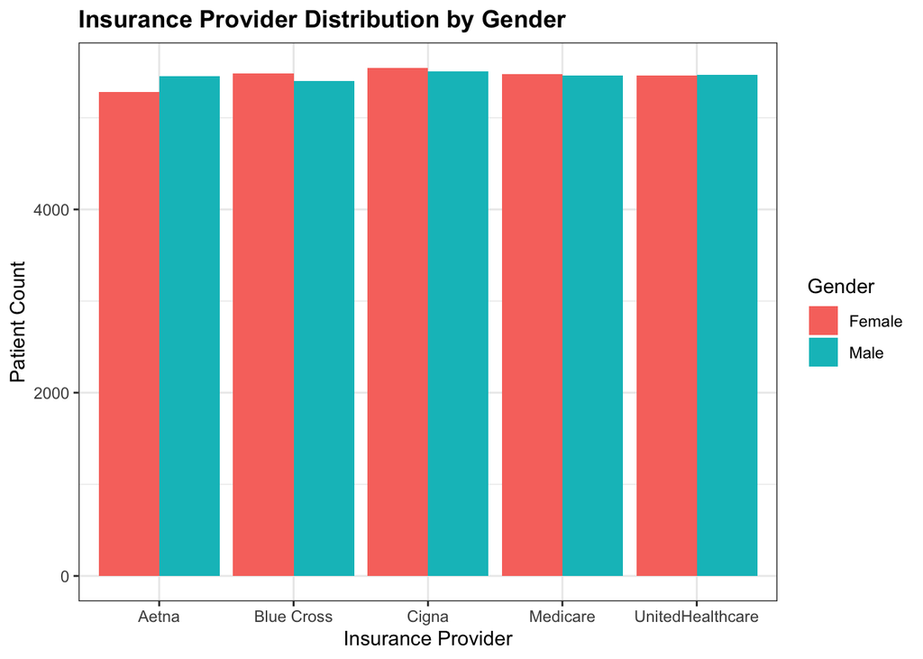

```r
# gender differences in insurance provider
ggplot(clean_dat1, aes(x = Insurance.Provider, fill = Gender)) +
  geom_bar(position = "dodge") +
  theme_bw() +
  labs(title = "Insurance Provider Distribution by Gender",
       x = "Insurance Provider", y = "Patient Count") +
  theme(plot.title = element_text(face = "bold"))
```

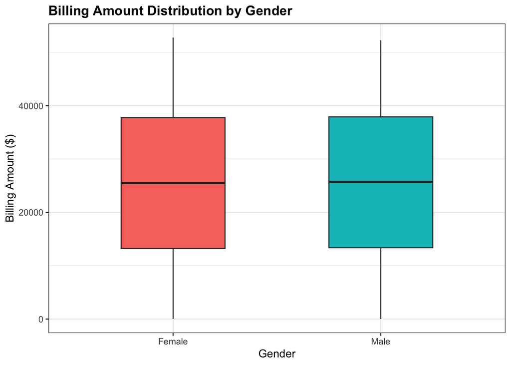

```r
# gender differences in billing amount
ggplot(clean_dat1, aes(x = Gender, y = Billing.Amount, fill = Gender)) +
  geom_boxplot(width = 0.5, outlier.alpha = 0.4) +
  theme_bw() +
  labs(title = "Billing Amount Distribution by Gender",
       x = "Gender", y = "Billing Amount ($)") +
  theme(legend.position = "none", plot.title = element_text(face = "bold"))
```

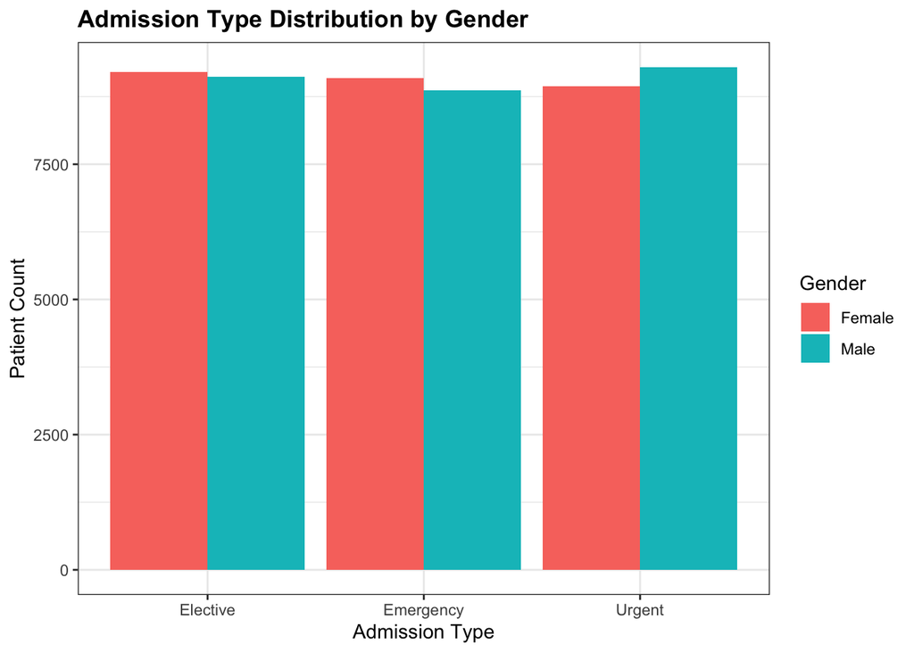

```r
# gender differences in admission type
ggplot(clean_dat1, aes(x = Admission.Type, fill = Gender)) +
  geom_bar(position = "dodge") +
  theme_bw() +
  labs(title = "Admission Type Distribution by Gender",
       x = "Admission Type", y = "Patient Count") +
  theme(plot.title = element_text(face = "bold"))
```

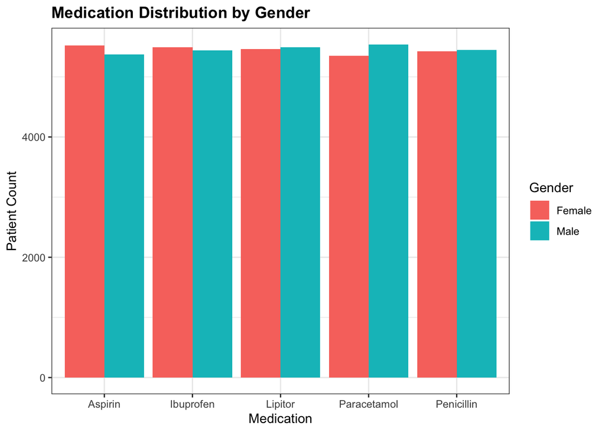

```r
# gender differences in Medication
ggplot(clean_dat1, aes(x = Medication, fill = Gender)) +
  geom_bar(position = "dodge") +
  theme_bw() +
  labs(title = "Medication Distribution by Gender",
       x = "Medication", y = "Patient Count") +
  theme(plot.title = element_text(face = "bold"))
```

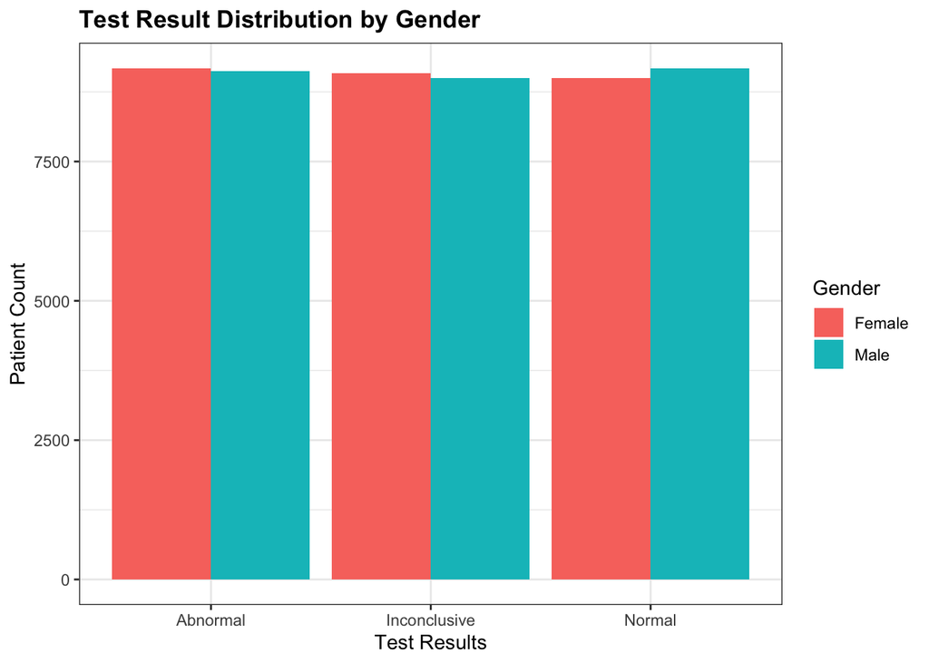

```r
# gender differences in Test Results
ggplot(clean_dat1, aes(x = Test.Results, fill = Gender)) +
  geom_bar(position = "dodge") +
  theme_bw() +
  labs(title = "Test Result Distribution by Gender",
       x = "Test Results", y = "Patient Count") +
  theme(plot.title = element_text(face = "bold"))
```

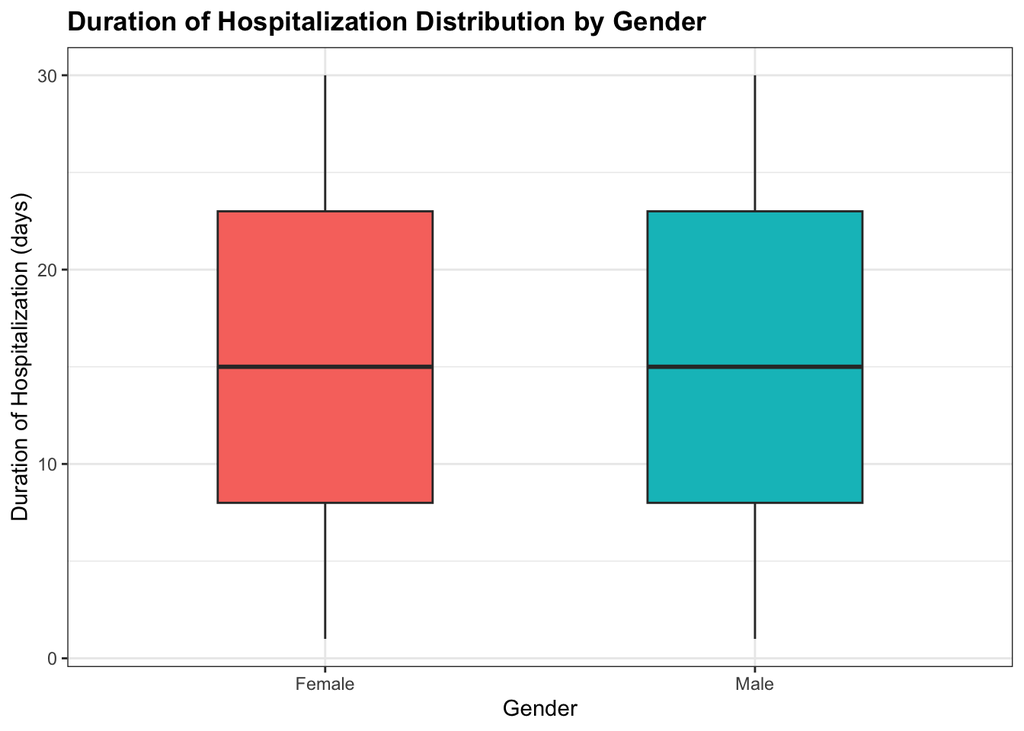

```r
# gender differences in duration of Hospitalization
ggplot(clean_dat1, aes(x = Gender, y = Duration.of.Hospitalization, fill = Gender)) +
  geom_boxplot(width = 0.5, outlier.alpha = 0.4) +
  theme_bw() +
  labs(title = "Duration of Hospitalization Distribution by Gender",
       x = "Gender", y = "Duration of Hospitalization (days)") +
  theme(legend.position = "none", plot.title = element_text(face = "bold"))
```

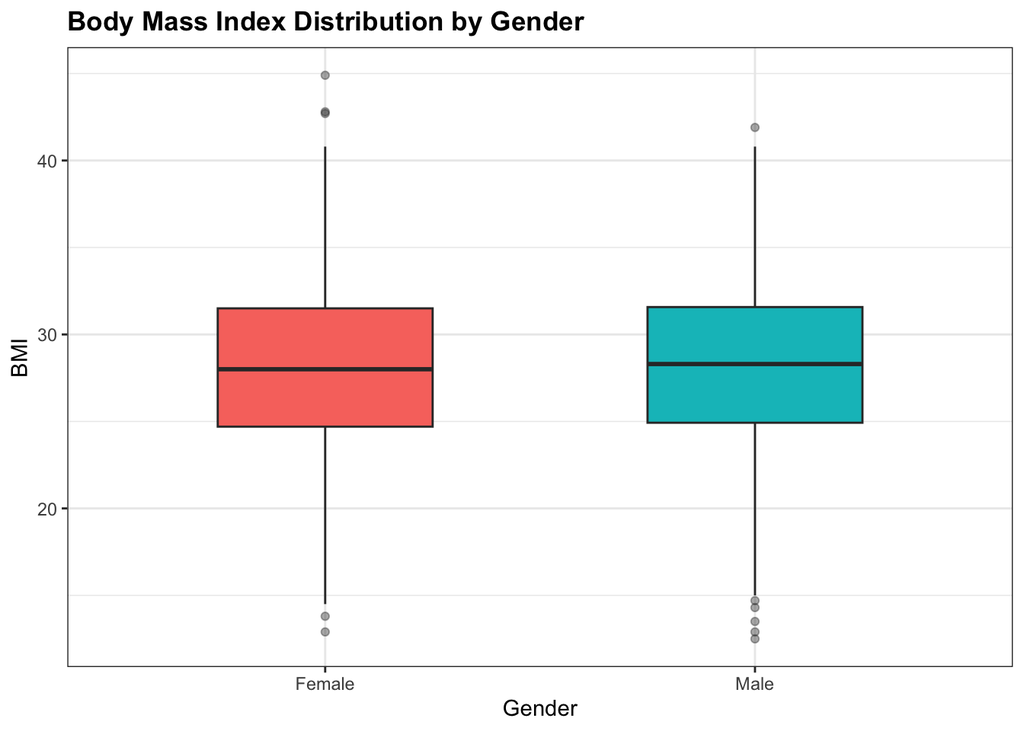

```r
# gender differences dat2
ggplot(clean_dat2, aes(x = gender, y = bmi, fill = gender)) +
  geom_boxplot(width = 0.5, outlier.alpha = 0.4) +
  theme_bw() +
  labs(title = "Body Mass Index Distribution by Gender",
       x = "Gender", y = "BMI") +
  theme(legend.position = "none", plot.title = element_text(face = "bold"))
```

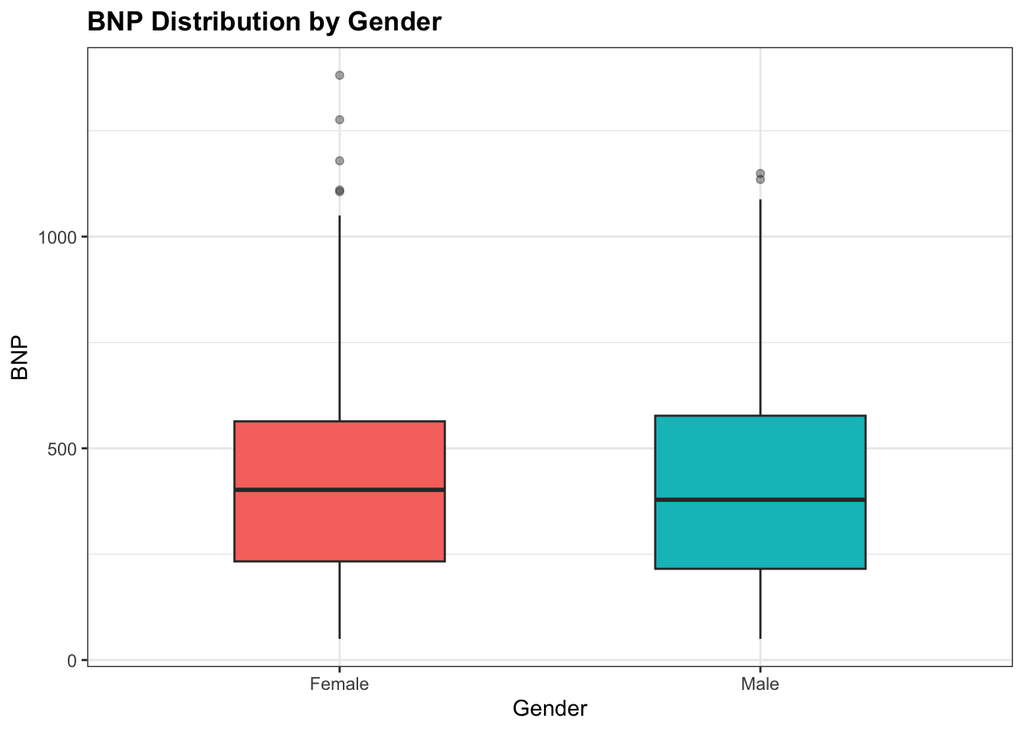

```r
# gender differences bnp
ggplot(clean_dat2, aes(x = gender, y = bnp, fill = gender)) +
  geom_boxplot(width = 0.5, outlier.alpha = 0.4) +
  theme_bw() +
  labs(title = "BNP Distribution by Gender", x = "Gender", y = "BNP") +
  theme(legend.position = "none", plot.title = element_text(face = "bold"))
```

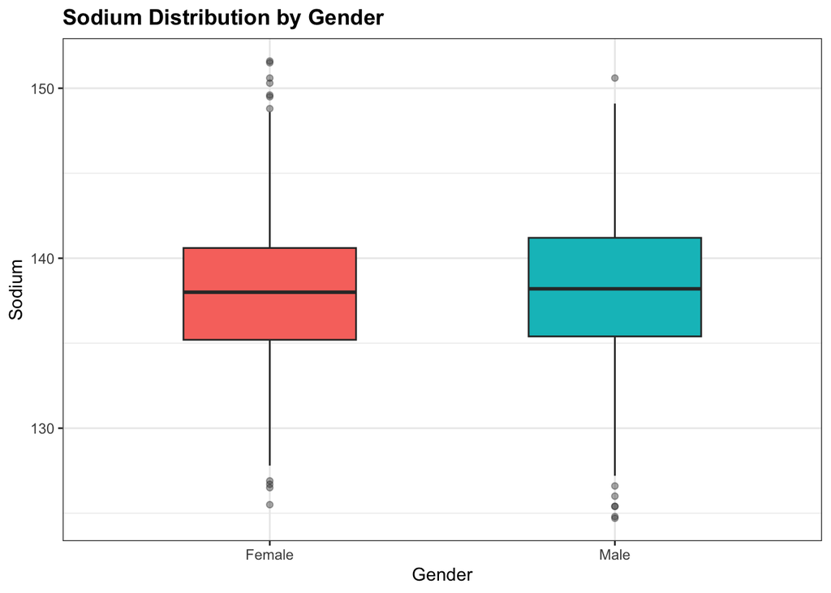

```r
# gender differences sodium
ggplot(clean_dat2, aes(x = gender, y = sodium, fill = gender)) +
  geom_boxplot(width = 0.5, outlier.alpha = 0.4) +
  theme_bw() +
  labs(title = "Sodium Distribution by Gender", x = "Gender", y = "Sodium") +
  theme(legend.position = "none", plot.title = element_text(face = "bold"))
```

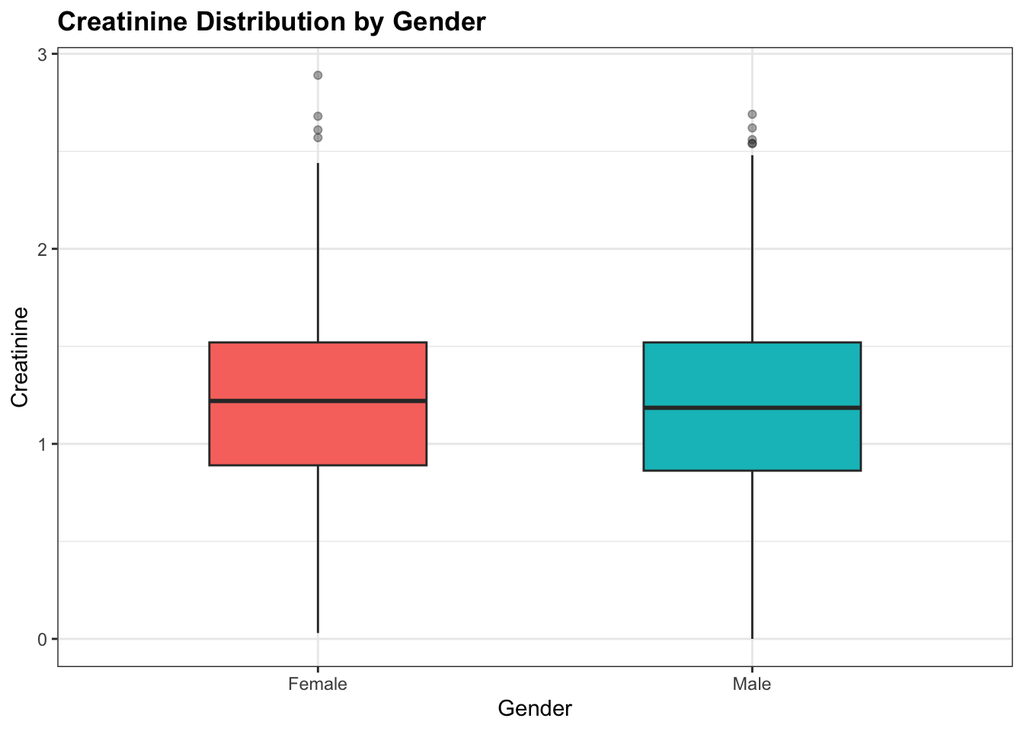

```r
# gender differences creatinine
ggplot(clean_dat2, aes(x = gender, y = creatinine, fill = gender)) +
  geom_boxplot(width = 0.5, outlier.alpha = 0.4) +
  theme_bw() +
  labs(title = "Creatinine Distribution by Gender", x = "Gender", y = "Creatinine") +
  theme(legend.position = "none", plot.title = element_text(face = "bold"))
```

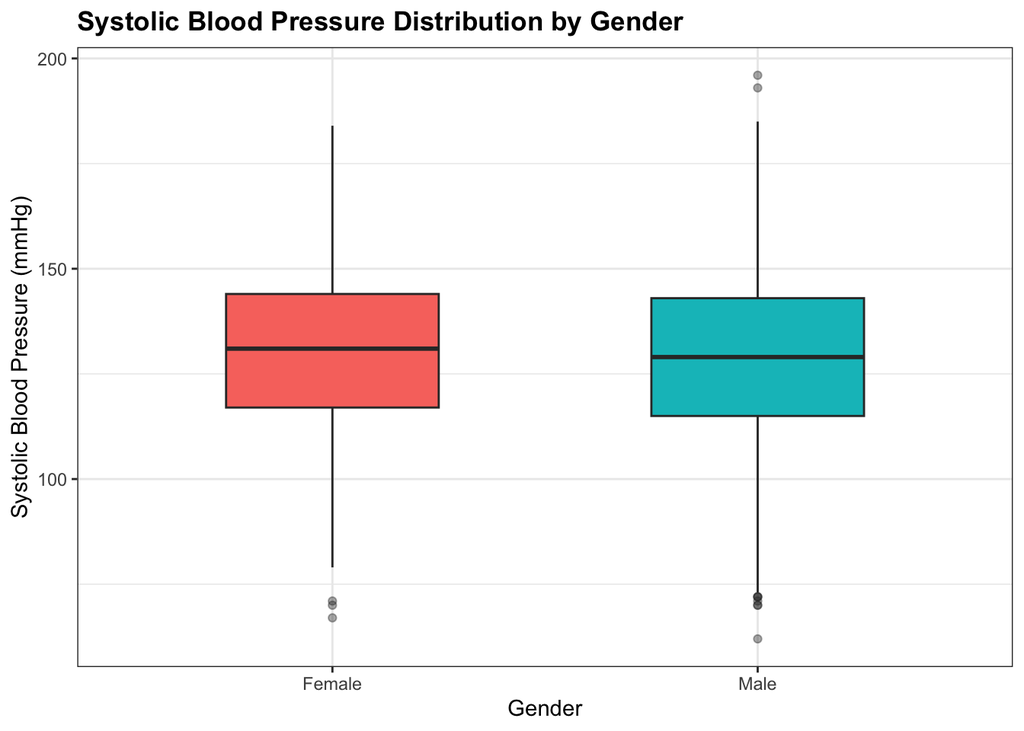

```r
# gender differences systolic_bp
ggplot(clean_dat2, aes(x = gender, y = systolic_bp, fill = gender)) +
  geom_boxplot(width = 0.5, outlier.alpha = 0.4) +
  theme_bw() +
  labs(title = "Systolic Blood Pressure Distribution by Gender", x = "Gender", y = "Systolic Blood Pressure (mmHg)") +
  theme(legend.position = "none", plot.title = element_text(face = "bold"))
```

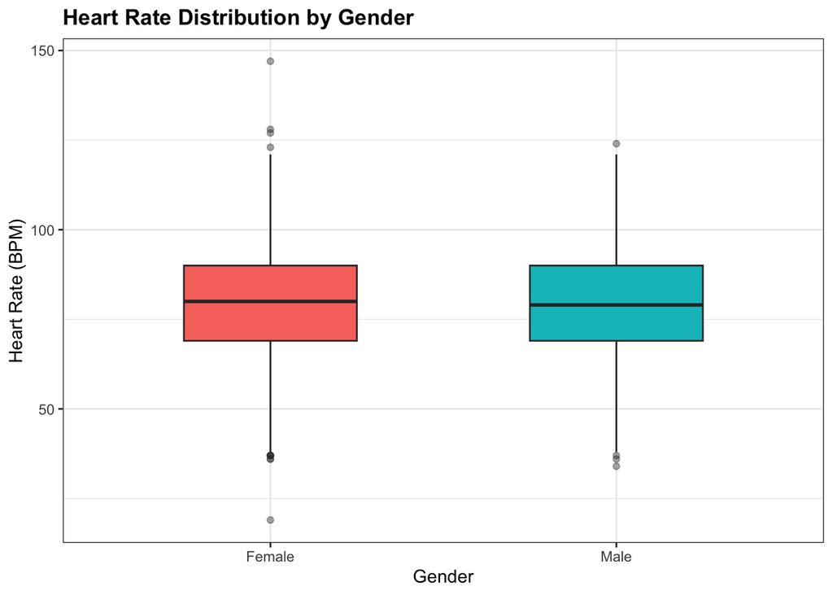

```r
# gender differences heart rate
ggplot(clean_dat2, aes(x = gender, y = heart_rate, fill = gender)) +
  geom_boxplot(width = 0.5, outlier.alpha = 0.4) +
  theme_bw() +
  labs(title = "Heart Rate Distribution by Gender", x = "Gender", y = "Heart Rate (BPM)") +
  theme(legend.position = "none", plot.title = element_text(face = "bold"))
```

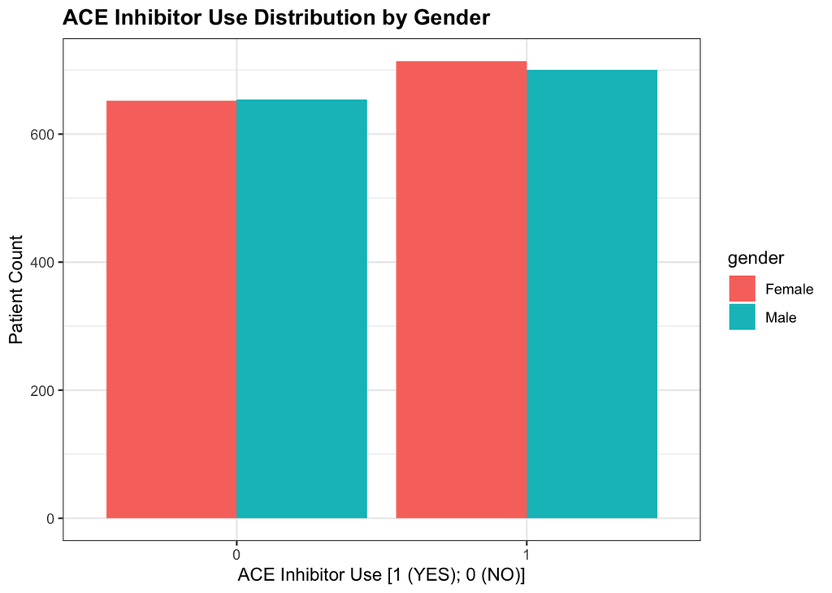

```r
# gender differences ace inhibitor
ggplot(clean_dat2, aes(x = ace_inhibitor, fill = gender)) +
  geom_bar(position = "dodge") +
  theme_bw() +
  labs(title = "ACE Inhibitor Use Distribution by Gender", x = "ACE Inhibitor Use [1 (YES); 0 (NO)]", y = "Patient Count") +
  theme(plot.title = element_text(face = "bold"))
```

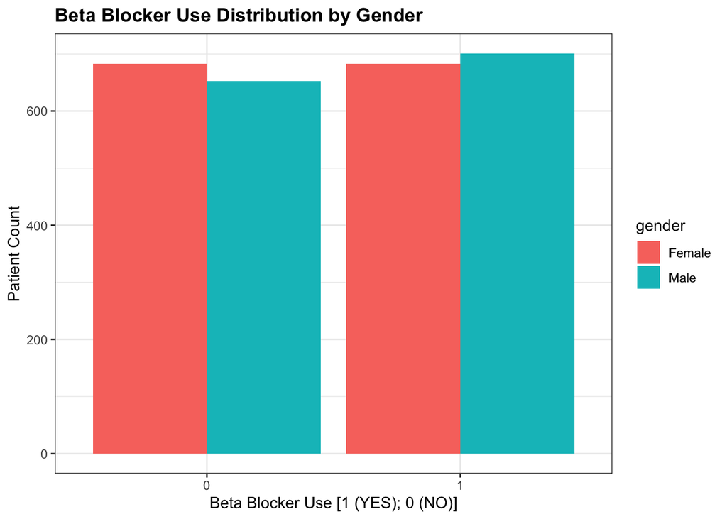

```r
# gender differences beta blocker
ggplot(clean_dat2, aes(x = beta_blocker, fill = gender)) +
  geom_bar(position = "dodge") +
  theme_bw() +
  labs(title = "Beta Blocker Use Distribution by Gender", x = "Beta Blocker Use [1 (YES); 0 (NO)]", y = "Patient Count") +
  theme(plot.title = element_text(face = "bold"))
```

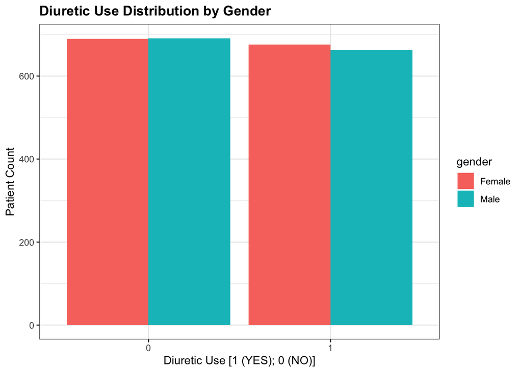

```r
# gender differences diuretic
ggplot(clean_dat2, aes(x = diuretic, fill = gender)) +
  geom_bar(position = "dodge") +
  theme_bw() +
  labs(title = "Diuretic Use Distribution by Gender", x = "Diuretic Use [1 (YES); 0 (NO)]", y = "Patient Count") +
  theme(plot.title = element_text(face = "bold"))
```

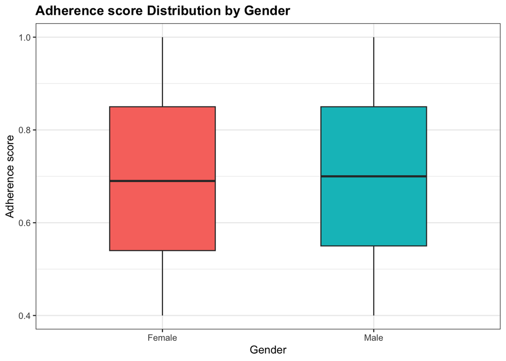

```r
# gender differences adherence score
ggplot(clean_dat2, aes(x = gender, y = adherence_score, fill = gender)) +
  geom_boxplot(width = 0.5, outlier.alpha = 0.4) +
  theme_bw() +
  labs(title = "Adherence score Distribution by Gender", x = "Gender", y = "Adherence score") +
  theme(legend.position = "none", plot.title = element_text(face = "bold"))
```

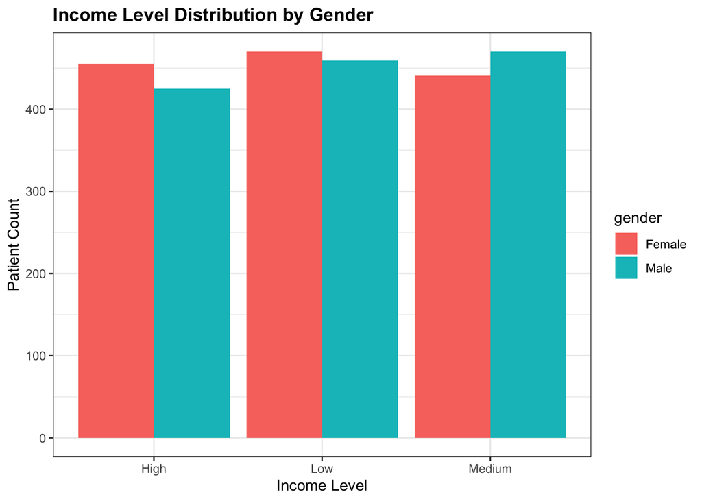

```r
# gender differences income level
ggplot(clean_dat2, aes(x = income_level, fill = gender)) +
  geom_bar(position = "dodge") +
  theme_bw() +
  labs(title = "Income Level Distribution by Gender", x = "Income Level", y = "Patient Count") +
  theme(plot.title = element_text(face = "bold"))
```

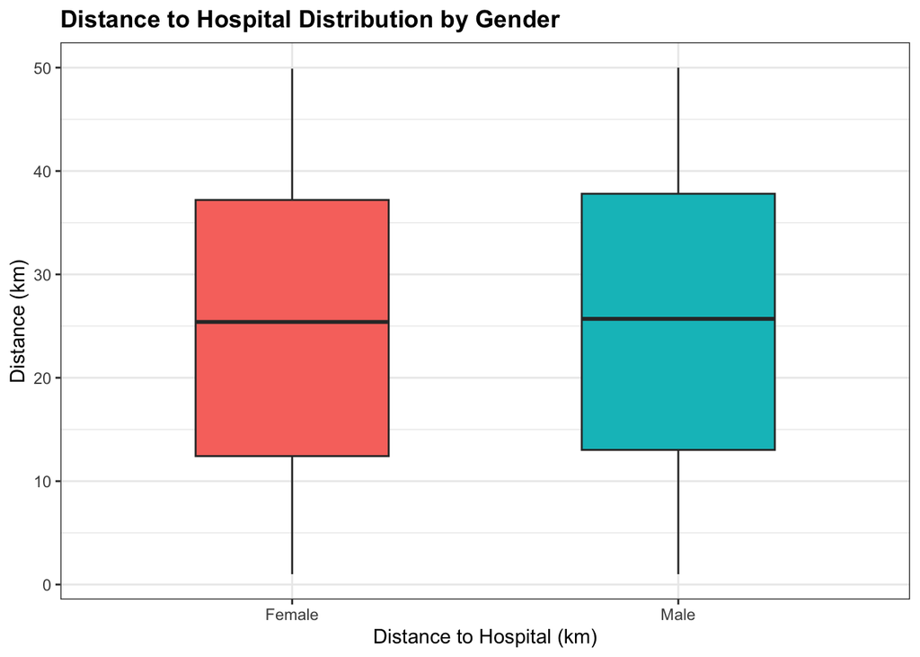

```r
# gender differences distance to hospital
ggplot(clean_dat2, aes(x = gender, y = distance_to_hospital_km, fill = gender)) +
  geom_boxplot(width = 0.5, outlier.alpha = 0.4) +
  theme_bw() +
  labs(title = "Distance to Hospital Distribution by Gender", x = "Distance to Hospital (km)", y = "Distance (km)") +
  theme(legend.position = "none", plot.title = element_text(face = "bold"))
```

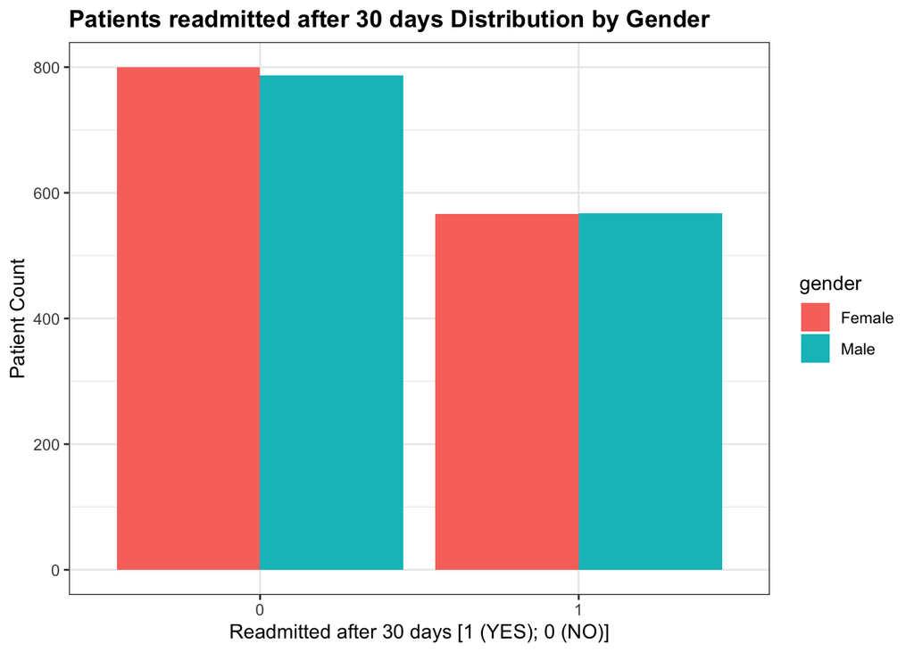

```r
# gender differences readmitted 30 days
ggplot(clean_dat2, aes(x = readmitted_30d, fill = gender)) +
  geom_bar(position = "dodge") +
  theme_bw() +
  labs(title = "Patients readmitted after 30 days Distribution by Gender", x = "Readmitted after 30 days [1 (YES); 0 (NO)]", y = "Patient Count") +
  theme(plot.title = element_text(face = "bold"))
```

# 3 Task 2

The following tasks refer to: Exam data 6 1.csv Investigate the effect of the following variables on the billing amount: 1. Date of admission 2. Duration of stay 3. Medical condition

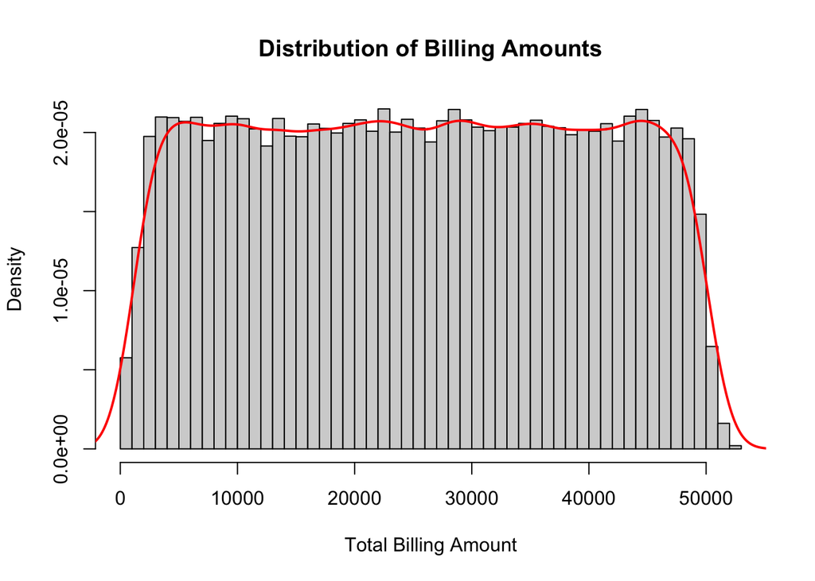

```r
clean_dat1$Admission_Year <- as.factor(format(as.Date(clean_dat1$Date.of.Admission), "%Y"))

# Check the skewness of billing
hist(clean_dat1$Billing.Amount,
     probability = TRUE,
     breaks = 50,
     main = "Distribution of Billing Amounts",
     xlab = "Total Billing Amount",
     col = "lightgray")
lines(density(clean_dat1$Billing.Amount, na.rm = TRUE), col = "red",  lwd = 2)
```

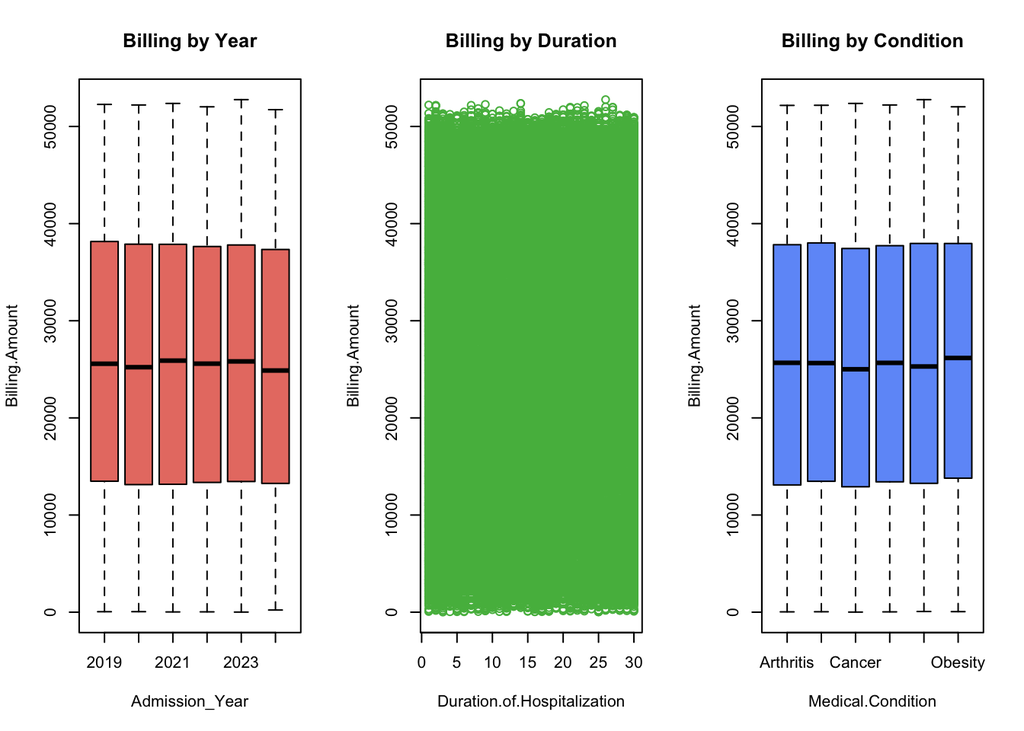

```r
# First visualize the data
par(mfrow = c(1, 3))

plot(Billing.Amount ~ Admission_Year, data = clean_dat1,
     main = "Billing by Year", col = "#E87D72")
plot(Billing.Amount ~ Duration.of.Hospitalization, data = clean_dat1,
     main = "Billing by Duration", col = "#54B84C")
plot(Billing.Amount ~ Medical.Condition, data = clean_dat1,
     main = "Billing by Condition", col = "#6F9BF8")
```

```r
par(mfrow = c(1, 1))

# Second run bivariate models

# 1. Effect of Time alone

# Run the updated bivariate model
model_year <- lm(Billing.Amount ~ Admission_Year, data = clean_dat1)
summary(model_year)
```

```
##
## Call:
## lm(formula = Billing.Amount ~ Admission_Year, data = clean_dat1)
##
## Residuals:
##      Min       1Q   Median       3Q      Max
## -25713.1 -12280.4      9.4  12227.0  27145.3
##
## Coefficients:
##                    Estimate Std. Error t value Pr(>|t|)
## (Intercept)        25759.93     166.63 154.593   <2e-16 ***
## Admission_Year2020  -312.78     214.15  -1.461    0.144
## Admission_Year2021   -96.78     215.65  -0.449    0.654
## Admission_Year2022  -173.69     215.22  -0.807    0.420
## Admission_Year2023  -140.91     215.09  -0.655    0.512
## Admission_Year2024  -325.32     284.10  -1.145    0.252
## ---
## Signif. codes:  0 '***' 0.001 '**' 0.01 '*' 0.05 '.' 0.1 ' ' 1
##
## Residual standard error: 14170 on 54530 degrees of freedom
## Multiple R-squared:  5.418e-05,  Adjusted R-squared:  -3.751e-05
## F-statistic: 0.5909 on 5 and 54530 DF,  p-value: 0.707
```

```r
# 2. Effect of Hospitalization Duration alone
model_duration <- lm(Billing.Amount ~ Duration.of.Hospitalization, data = clean_dat1)
summary(model_duration)
```

```
##
## Call:
## lm(formula = Billing.Amount ~ Duration.of.Hospitalization, data = clean_dat1)
##
## Residuals:
##      Min       1Q   Median       3Q      Max
## -25671.5 -12292.5     -4.8  12230.6  27246.6
##
## Coefficients:
##                              Estimate Std. Error t value Pr(>|t|)
## (Intercept)                 25701.984    124.444 206.534   <2e-16 ***
## Duration.of.Hospitalization    -7.090      7.008  -1.012    0.312
## ---
## Signif. codes:  0 '***' 0.001 '**' 0.01 '*' 0.05 '.' 0.1 ' ' 1
##
## Residual standard error: 14170 on 54534 degrees of freedom
## Multiple R-squared:  1.877e-05,  Adjusted R-squared:  4.324e-07
## F-statistic: 1.024 on 1 and 54534 DF,  p-value: 0.3117
```

```r
# 3. Effect of Medical Condition alone
model_condition <- lm(Billing.Amount ~ Medical.Condition, data = clean_dat1)
summary(model_condition)
```

```
##
## Call:
## lm(formula = Billing.Amount ~ Medical.Condition, data = clean_dat1)
##
## Residuals:
##      Min       1Q   Median       3Q      Max
## -25798.1 -12270.1      0.7  12220.8  27235.1
##
## Coefficients:
##                               Estimate Std. Error t value Pr(>|t|)
## (Intercept)                   25570.96     148.06 172.712   <2e-16 ***
## Medical.ConditionAsthma         102.03     210.20   0.485   0.6274
## Medical.ConditionCancer        -350.29     209.90  -1.669   0.0952 .
## Medical.ConditionDiabetes       135.64     209.53   0.647   0.5174
## Medical.ConditionHypertension   -41.82     209.91  -0.199   0.8421
## Medical.ConditionObesity        281.06     209.92   1.339   0.1806
## ---
## Signif. codes:  0 '***' 0.001 '**' 0.01 '*' 0.05 '.' 0.1 ' ' 1
##
## Residual standard error: 14170 on 54530 degrees of freedom
## Multiple R-squared:  0.0001902,  Adjusted R-squared:  9.85e-05
## F-statistic: 2.074 on 5 and 54530 DF,  p-value: 0.06537
```

```r
# Then combined model
model_combined <- lm(Billing.Amount ~ Admission_Year + Duration.of.Hospitalization + Medical.Condition, data = clean_dat1)
summary(model_combined)
```

```
##
## Call:
## lm(formula = Billing.Amount ~ Admission_Year + Duration.of.Hospitalization +
##     Medical.Condition, data = clean_dat1)
##
## Residuals:
##      Min       1Q   Median       3Q      Max
## -25795.2 -12276.6     -2.8  12234.9  27282.8
##
## Coefficients:
##                                Estimate Std. Error t value Pr(>|t|)
## (Intercept)                   25853.150    241.186 107.192   <2e-16 ***
## Admission_Year2020             -316.423    214.172  -1.477   0.1396
## Admission_Year2021             -103.293    215.665  -0.479   0.6320
## Admission_Year2022             -178.306    215.239  -0.828   0.4074
## Admission_Year2023             -145.430    215.101  -0.676   0.4990
## Admission_Year2024             -328.076    284.107  -1.155   0.2482
## Duration.of.Hospitalization      -7.026      7.009  -1.002   0.3161
## Medical.ConditionAsthma         100.279    210.217   0.477   0.6333
## Medical.ConditionCancer        -351.929    209.921  -1.676   0.0936 .
## Medical.ConditionDiabetes       132.779    209.548   0.634   0.5263
## Medical.ConditionHypertension   -43.535    209.925  -0.207   0.8357
## Medical.ConditionObesity        280.780    209.948   1.337   0.1811
## ---
## Signif. codes:  0 '***' 0.001 '**' 0.01 '*' 0.05 '.' 0.1 ' ' 1
##
## Residual standard error: 14170 on 54524 degrees of freedom
## Multiple R-squared:  0.0002632,  Adjusted R-squared:  6.154e-05
## F-statistic: 1.305 on 11 and 54524 DF,  p-value: 0.2139
```

# 4 Task 3

The following tasks refer to: Exam data 6 1.csv 1. For this task remove all observations with inconclusive test results. 2. Fit a logistic regression model with test result as the dependent outcome. You are free to choose which independent variables to include.

```r
# 3.1 Remove all observations with inconclusive test results
dat1_conclusive <- clean_dat1[clean_dat1$Test.Results != "Inconclusive", ]
dat1_conclusive$Test.Results <- droplevels(dat1_conclusive$Test.Results)

# Check remaining levels
table(dat1_conclusive$Test.Results)
```

```
##
## Abnormal   Normal
##    18285    18176
```

```r
# 3.2  Logistic regression with the test result as outcome
# Create binary outcome: 1 = Abnormal, 0 = Normal
dat1_conclusive$Test_binary <- 0
dat1_conclusive[dat1_conclusive$Test.Results == "Abnormal", "Test_binary"] <- 1

# Fit logistic regression: use age, gender, medical condition, admission type, duration
mod_logit <- glm(Test_binary ~ Age + Gender + Medical.Condition +
                   Admission.Type + Duration.of.Hospitalization,
                 data = dat1_conclusive,
                 family = binomial)
summary(mod_logit)
```

```
##
## Call:
## glm(formula = Test_binary ~ Age + Gender + Medical.Condition +
##     Admission.Type + Duration.of.Hospitalization, family = binomial,
##     data = dat1_conclusive)
##
## Coefficients:
##                                 Estimate Std. Error z value Pr(>|z|)
## (Intercept)                    0.0318033  0.0456134   0.697  0.48566
## Age                            0.0007907  0.0005336   1.482  0.13837
## GenderMale                    -0.0239577  0.0209546  -1.143  0.25291
## Medical.ConditionAsthma       -0.1010315  0.0363022  -2.783  0.00538 **
## Medical.ConditionCancer       -0.0269746  0.0362726  -0.744  0.45708
## Medical.ConditionDiabetes     -0.0270605  0.0361484  -0.749  0.45410
## Medical.ConditionHypertension -0.0891172  0.0363126  -2.454  0.01412 *
## Medical.ConditionObesity      -0.0242564  0.0362375  -0.669  0.50326
## Admission.TypeEmergency       -0.0101707  0.0256671  -0.396  0.69192
## Admission.TypeUrgent           0.0025938  0.0255780   0.101  0.91923
## Duration.of.Hospitalization   -0.0004803  0.0012125  -0.396  0.69202
## ---
## Signif. codes:  0 '***' 0.001 '**' 0.01 '*' 0.05 '.' 0.1 ' ' 1
##
## (Dispersion parameter for binomial family taken to be 1)
##
##     Null deviance: 50545  on 36460  degrees of freedom
## Residual deviance: 50529  on 36450  degrees of freedom
## AIC: 50551
##
## Number of Fisher Scoring iterations: 3
```

```r
# Alternative model with fewer predictors
mod_logit2 <- glm(Test_binary ~ Age + Medical.Condition + Duration.of.Hospitalization,
                  data = dat1_conclusive,
                  family = binomial)
summary(mod_logit2)
```

```
##
## Call:
## glm(formula = Test_binary ~ Age + Medical.Condition + Duration.of.Hospitalization,
##     family = binomial, data = dat1_conclusive)
##
## Coefficients:
##                                 Estimate Std. Error z value Pr(>|z|)
## (Intercept)                    0.0174181  0.0419200   0.416  0.67777
## Age                            0.0007909  0.0005336   1.482  0.13830
## Medical.ConditionAsthma       -0.1010491  0.0363007  -2.784  0.00537 **
## Medical.ConditionCancer       -0.0271076  0.0362707  -0.747  0.45484
## Medical.ConditionDiabetes     -0.0271330  0.0361475  -0.751  0.45288
## Medical.ConditionHypertension -0.0892064  0.0363104  -2.457  0.01402 *
## Medical.ConditionObesity      -0.0245017  0.0362352  -0.676  0.49892
## Duration.of.Hospitalization   -0.0004821  0.0012124  -0.398  0.69091
## ---
## Signif. codes:  0 '***' 0.001 '**' 0.01 '*' 0.05 '.' 0.1 ' ' 1
##
## (Dispersion parameter for binomial family taken to be 1)
##
##     Null deviance: 50545  on 36460  degrees of freedom
## Residual deviance: 50531  on 36453  degrees of freedom
## AIC: 50547
##
## Number of Fisher Scoring iterations: 3
```

```r
# Compare AIC of both models
AIC(mod_logit, mod_logit2)
```

```
##            df      AIC
## mod_logit  11 50551.07
## mod_logit2  8 50546.64
```

```r
anova(mod_logit2, mod_logit, test = "LRT")
```

```
## Analysis of Deviance Table
##
## Model 1: Test_binary ~ Age + Medical.Condition + Duration.of.Hospitalization
## Model 2: Test_binary ~ Age + Gender + Medical.Condition + Admission.Type +
##     Duration.of.Hospitalization
##   Resid. Df Resid. Dev Df Deviance Pr(>Chi)
## 1     36453      50531
## 2     36450      50529  3   1.5691   0.6664
```

# 5 Task 4

The following tasks refer to: Exam data 6 2.csv Income analysis: 1. Is there an association between the income level and the distance to the hospital? 2. Are there any clinical variables which differ significantly between income levels? 3. How is age distributed in each income level?

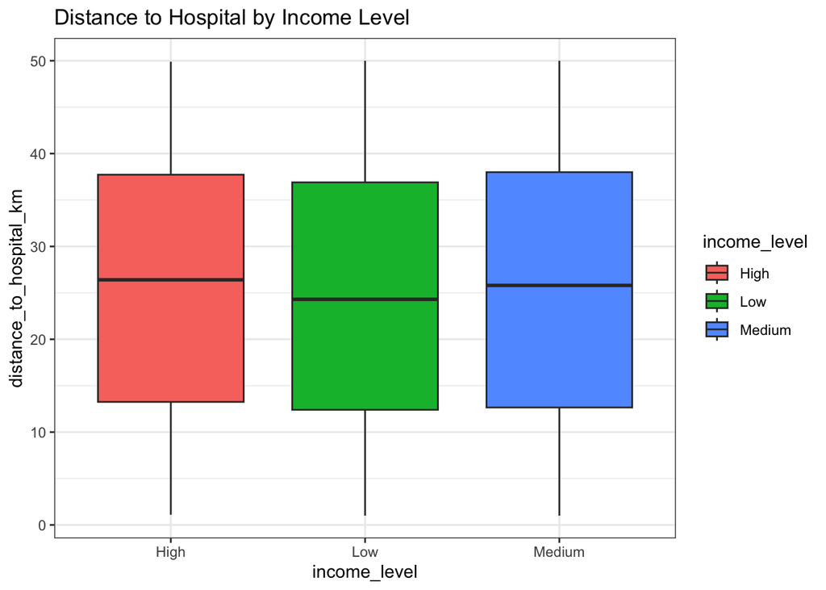

```r
# 4.1 Association between income level and distance to the hospital?
ggplot(clean_dat2, aes(x = income_level, y = distance_to_hospital_km, fill = income_level)) +
  geom_boxplot() +
  ggtitle("Distance to Hospital by Income Level") +
  theme_bw()
```

```r
# Mean distance per income level
tapply(clean_dat2$distance_to_hospital_km, clean_dat2$income_level, mean)
```

```
##     High      Low   Medium
## 25.86943 24.81507 25.52272
```

```r
# income_level has 3 groups, so we use ANOVA
anova_dist <- aov(distance_to_hospital_km ~ income_level, data = clean_dat2)
summary(anova_dist)
```

```
##                Df Sum Sq Mean Sq F value Pr(>F)
## income_level    2    525   262.7   1.299  0.273
## Residuals    2717 549265   202.2
```

```r
# 4.2  Are there any clinical variables which differ significantly between income levels?
summary(aov(bmi             ~ income_level, data = clean_dat2))
```

```
##                Df Sum Sq Mean Sq F value Pr(>F)
## income_level    2     30   14.98   0.615  0.541
## Residuals    2717  66170   24.35
```

```r
summary(aov(bnp             ~ income_level, data = clean_dat2))
```

```
##                Df    Sum Sq Mean Sq F value Pr(>F)
## income_level    2    159904   79952   1.477  0.228
## Residuals    2717 147037562   54118
```

```r
summary(aov(sodium          ~ income_level, data = clean_dat2))
```

```
##                Df Sum Sq Mean Sq F value Pr(>F)
## income_level    2      9   4.313   0.266  0.767
## Residuals    2717  44141  16.246
```

```r
summary(aov(creatinine      ~ income_level, data = clean_dat2))
```

```
##                Df Sum Sq Mean Sq F value Pr(>F)
## income_level    2    0.1 0.04697   0.208  0.812
## Residuals    2717  614.2 0.22605
```

```r
summary(aov(systolic_bp     ~ income_level, data = clean_dat2))
```

```
##                Df  Sum Sq Mean Sq F value Pr(>F)
## income_level    2    1480   740.2   1.819  0.162
## Residuals    2717 1105770   407.0
```

```r
summary(aov(heart_rate      ~ income_level, data = clean_dat2))
```

```
##                Df Sum Sq Mean Sq F value Pr(>F)
## income_level    2    154   77.05   0.333  0.717
## Residuals    2717 629341  231.63
```

```r
summary(aov(adherence_score ~ income_level, data = clean_dat2))
```

```
##                Df Sum Sq Mean Sq F value Pr(>F)
## income_level    2   0.06 0.03154   1.045  0.352
## Residuals    2717  82.03 0.03019
```

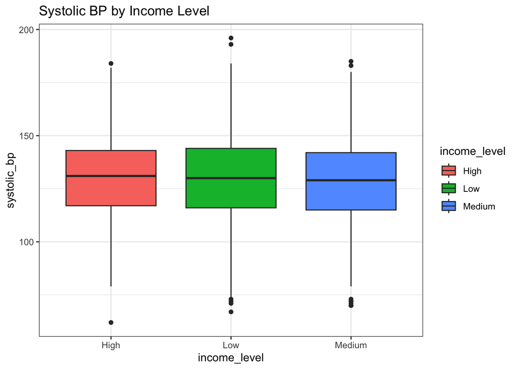

```r
# Nothing is significant, lets just visualize one with lower p-value
ggplot(clean_dat2, aes(x = income_level, y = systolic_bp, fill = income_level)) +
  geom_boxplot() +
  ggtitle("Systolic BP by Income Level") +
  theme_bw()
```

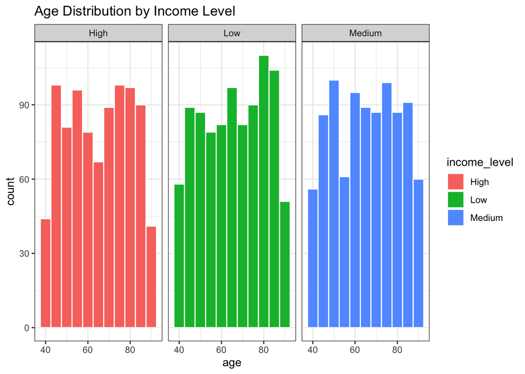

```r
# 4.3 How is age distributed in each income level?
ggplot(clean_dat2, aes(x = age, fill = income_level)) +
  geom_histogram(binwidth = 5, color = "white") +
  facet_wrap(~ income_level) +
  ggtitle("Age Distribution by Income Level") +
  theme_bw()
```

```r
# Summary statistics
tapply(clean_dat2$age, clean_dat2$income_level, summary)
```

```
## $High
##    Min. 1st Qu.  Median    Mean 3rd Qu.    Max.
##   40.00   52.00   66.00   65.11   78.00   90.00
##
## $Low
##    Min. 1st Qu.  Median    Mean 3rd Qu.    Max.
##   40.00   52.00   66.00   65.67   79.00   90.00
##
## $Medium
##    Min. 1st Qu.  Median    Mean 3rd Qu.    Max.
##   40.00   52.00   65.00   65.34   78.00   90.00
```